# STT 301 Learning R Markdown - Part 2

Rellika Kisyula

September 10, 2018

Use R Markdown to recreate the document `ica-solutions-09-05-18`. Everything should be exactly the same except your name should go in place of “Shawn Santo”.

You may want to consult the R Markdown [authoring basics](http://rmarkdown.rstudio.com/authoring_basics.html), the [R Markdown Cheat Sheet](https://www.rstudio.com/wp-content/uploads/2015/02/rmarkdown-cheatsheet.pdf), and the [R Markdown Reference](https://www.rstudio.com/wp-content/uploads/2015/03/rmarkdown-reference.pdf), along with the Chapter 3 course notes as you work.

To get you started, the first code chunk contains

`library(knitr)`

`load("baseball.Rdata")`

with the option `include=FALSE`, which is why you do not see it in the HTML solutions. You will need to make sure the file `baseball.Rdata` is in the same directory as your working directory for your .Rmd file.

A few notes on `ica-solutions-09-05-18`:

1. I used second level headers for the main parts
2. I used third level headers for the sub-parts
3. Don’t forget to include the URL links

```r
library(knitr)
load("baseball.Rdata")
```

# Introduction

**Learning objectives:**

- Functions for descriptive statistics
- Variable assignment
- Data subsetting

The `Lahman` package in `R` contains a plethora of baseball data. The package is used extensively in the book, “Analyzing Baseball Data with R”, by Max Marchi and Jim Albert (2013). This tutorial will use a subset of data from the `Lahman` package to expose you to some basic descriptive statistical functions and data subsetting.

The subset of data from the `Lahman` package is automatically loaded at the start of this tutorial. You will learn how to read in different data files later.

# Data analysis basics - part 1

### Accessing data

To see all the objects loaded from the baseball data set in this tutorial use the function ls(). Function ls() lists all the objects in the current environment. However, since only a subset of the Lahman package is loaded, ls() will only show those objects corresponding to the baseball data set.

```r
ls()
```

```
##  [1] "batting_stats"  "CarltonFiskBA"  "CarltonFiskHR"  "CarltonFiskRBI"
##  [5] "JimRiceBA"      "JimRiceHR"      "JimRiceRBI"     "team_abrev"
##  [9] "TedWilliamsBA"  "TedWilliamsHR"  "TedWilliamsRBI"
```

To access the content of an object in R use the object’s name. Keep in mind that R is case sensitive. Thus, we need to type an object’s name exactly as it appears.

Above we see the object `JimRiceBA`. Run the code below to see the contents of `JimRiceBA`.

```r
JimRiceBA
```

```
##  1974  1975  1976  1977  1978  1979  1980  1981  1982  1983  1984  1985
## 0.269 0.309 0.282 0.320 0.315 0.325 0.294 0.284 0.309 0.305 0.280 0.291
##  1986  1987  1988  1989
## 0.324 0.277 0.264 0.234
```

### Descriptive statistics

The names of many functions in `R` are self-explanatory. To compute the minimum, maximum, and mean for Jim Rice’s career batting average we can use the corresponding functions given below.

```r
min(JimRiceBA)
```

```
## [1] 0.234
```

```r
max(JimRiceBA)
```

```
## [1] 0.325
```

```r
mean(JimRiceBA)
```

```
## [1] 0.292625
```

To find the year in which Jim Rice had his lowest batting average and the year in which he had his highest batting average, we can make use of the functions `which.min()` and `which.max()`, respectively.

```r
which.min(JimRiceBA)
```

```
## 1989
##   16
```

```r
which.max(JimRiceBA)
```

```
## 1979
##    6
```

Let’s examine how Rice’s batting average changed throughout his career. First, we compute year-over-year differences, then view the results. Second, we will look at which year he had the largest increase and which year he had the largest decrease.

```r
# compute differences
JimRiceBA_diffs <- diff(JimRiceBA, lag = 1)
JimRiceBA_diffs
```

```
##   1975   1976   1977   1978   1979   1980   1981   1982   1983   1984
##  0.040 -0.027  0.038 -0.005  0.010 -0.031 -0.010  0.025 -0.004 -0.025
##   1985   1986   1987   1988   1989
##  0.011  0.033 -0.047 -0.013 -0.030
```

```r
# find years
which.max(JimRiceBA_diffs)
```

```
## 1975
##    1
```

```r
which.min(JimRiceBA_diffs)
```

```
## 1987
##   13
```

The `#` symbol was used to add comments. `R` does not execute anything following `#`. Use `#` for code documentation to explain to others why you are doing what you are doing. Good code documentation is also beneficial for your future self.

# Data analysis basics - part 2

### Summary statistics with two variables

Recall that the correlation measures the linear strength between two quantitative variables. Let’s look at the correlation between each pair of available variables for Jim Rice: batting average, home runs, and RBIs.

```r
cor(JimRiceBA, JimRiceHR)
```

```
## [1] 0.7576232
```

```r
cor(JimRiceBA, JimRiceRBI)
```

```
## [1] 0.7942272
```

```r
cor(JimRiceHR, JimRiceRBI)
```

```
## [1] 0.9305225
```

To view a simple plot of Rice’s home runs versus his RBIs we can use the `plot()` function.

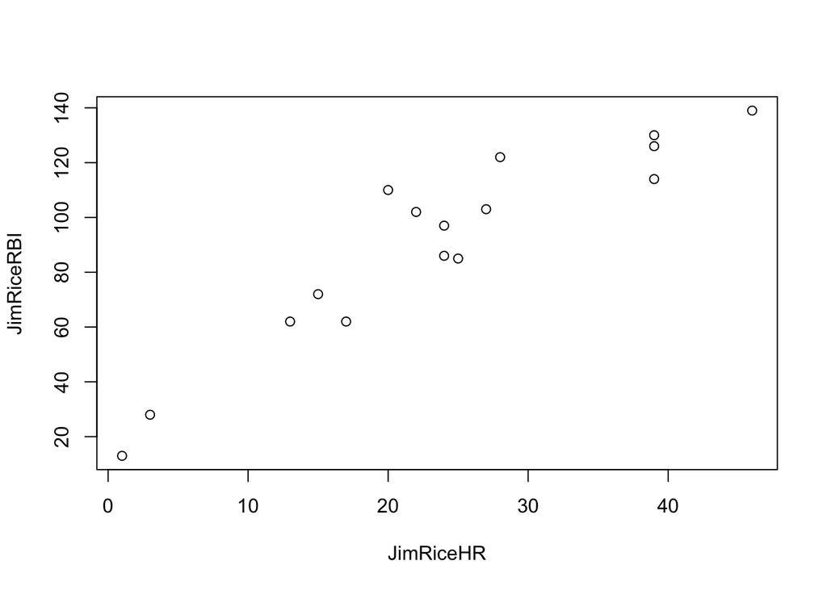

```r
plot(JimRiceHR, JimRiceRBI)
```

To learn more about Jim Rice click [here](https://en.wikipedia.org/wiki/Jim_Rice).

# Exercise 1

In the following exercises you use the data on [Ted Williams](https://en.wikipedia.org/wiki/Ted_Williams).

To remind yourself of the variable names use the function `ls()`.

### Part a

Use the `length()` function to determine how many seasons Ted Williams played.

```r
length(TedWilliamsBA)
```

```
## [1] 19
```

### Part b

What season did Ted Williams have his highest batting average?

```r
which.max(TedWilliamsBA)
```

```
## 1953
##   12
```

### Part c

What was Williams’ highest batting average?

```r
max(TedWilliamsBA)
```

```
## [1] 0.407
```

### Part d

What was Williams’ career mean batting average?

```r
mean(TedWilliamsBA)
```

```
## [1] 0.3475789
```

### Part e

What was the correlation between Williams’ home runs and RBIs? Was it higher than Jim Rice’s correlation?

```r
cor(TedWilliamsHR, TedWilliamsRBI)
```

```
## [1] 0.8422571
```

```r
cor(JimRiceHR, JimRiceRBI)
```

```
## [1] 0.9305225
```

Jim Rice had a high correlation between home runs and RBIs.

### Part f

What was the largest absolute change in Williams’ RBIs year-over-year?

```r
tw_rbi_diff <- diff(TedWilliamsRBI, lag = 1)
max(abs(tw_rbi_diff))
```

```
## [1] 123
```

# Data frames

### Subsetting

The `R` objects such as `JimRiceBA` and `TedWilliamsHR` are known as vectors. For now, think of a vector as data of the same form corresponding to one variable. In the following section and exercises you will work with data frames. Think of a data frame as table or a data set you would view in an excel spreadsheet. We will formally learn about vectors, data frames, and other data types of `R` later.

Among the objects loaded at the start of this tutorial was the data frame `batting_stats`. Each column of the data frame corresponds to a variable. Let’s see how many variables are in `batting_stats` as well as how many rows the data frame contains.

```r
names(batting_stats)
```

```
##  [1] "playerID"   "yearID"     "stint"      "teamID"     "lgID"
##  [6] "G"          "G_batting"  "AB"         "R"          "H"
## [11] "X2B"        "X3B"        "HR"         "RBI"        "SB"
## [16] "CS"         "BB"         "SO"         "IBB"        "HBP"
## [21] "SH"         "SF"         "GIDP"       "G_old"      "BA"
## [26] "PA"         "TB"         "SlugPct"    "OBP"        "OPS"
## [31] "BABIP"      "playerName"
```

```r
dim(batting_stats)
```

```
## [1] 97889    32
```

We see that `batting_stats` has 97,889 rows and 32 variables, where the variable names are provided by the `names()` function.

One way to subset a data frame is to use `[ , ]` and specify row and column indices.

```r
batting_stats[90000, c(32, 25, 13, 14)]
```

```
##         playerName    BA HR RBI
## 90000 Tim Corcoran 0.214  0  22
```

```r
batting_stats[c(90000, 91000, 92000), c(32, 25, 13, 14)]
```

```
##         playerName    BA HR RBI
## 90000 Tim Corcoran 0.214  0  22
## 91000   Todd Zeile 0.273 18  87
## 92000 Tom Paciorek 0.284  1  11
```

A more informative and efficient way to subset a data frame is to use the `subset()` function. Let’s look at Jimmy Rollin’s batting average, home runs, and RBIs.

```r
jroll <- subset(batting_stats, playerName == "Jimmy Rollins")
jroll[, c(32, 25, 13, 14)]
```

```
##          playerName    BA HR RBI
## 51774 Jimmy Rollins 0.321  0   5
## 51775 Jimmy Rollins 0.274 14  54
## 51776 Jimmy Rollins 0.245 11  60
## 51777 Jimmy Rollins 0.263  8  62
## 51778 Jimmy Rollins 0.289 14  73
## 51779 Jimmy Rollins 0.290 12  54
## 51780 Jimmy Rollins 0.277 25  83
## 51781 Jimmy Rollins 0.296 30  94
## 51782 Jimmy Rollins 0.277 11  59
## 51783 Jimmy Rollins 0.250 21  77
## 51784 Jimmy Rollins 0.243  8  41
## 51785 Jimmy Rollins 0.268 16  63
## 51786 Jimmy Rollins 0.250 23  68
## 51787 Jimmy Rollins 0.252  6  39
```

Suppose we are interested in subsetting `batting_stats` based on the players with a batting average greater than 0.400 and who played in a minimum of 100 games.

```r
over400 <- subset(batting_stats, BA > 0.400 & G >= 100)
over400[, c("playerName", "BA", "G", "yearID")]
```

```
##                 playerName    BA   G yearID
## 7473            Bill Terry 0.401 154   1930
## 7913        Billy Hamilton 0.404 129   1894
## 29490         Ed Delahanty 0.407 114   1894
## 29491         Ed Delahanty 0.404 116   1895
## 29495         Ed Delahanty 0.410 146   1899
## 34966          Fred Dunlap 0.412 101   1884
## 38174        George Sisler 0.407 154   1920
## 38176        George Sisler 0.420 142   1922
## 41492       Harry Heilmann 0.403 144   1923
## 43455           Hugh Duffy 0.440 125   1894
## 43552      Hughie Jennings 0.401 130   1896
## 48887        Jesse Burkett 0.409 131   1895
## 48888        Jesse Burkett 0.410 133   1896
## 72064           Nap Lajoie 0.426 131   1901
## 75669        Pete Browning 0.402 134   1887
## 81888       Rogers Hornsby 0.401 154   1922
## 81890       Rogers Hornsby 0.424 143   1924
## 81891       Rogers Hornsby 0.403 138   1925
## 86618 Shoeless Joe Jackson 0.408 147   1911
## 89346         Ted Williams 0.406 143   1941
## 90595          Tip O'Neill 0.435 124   1887
## 94134              Ty Cobb 0.420 146   1911
## 94135              Ty Cobb 0.409 140   1912
## 94145              Ty Cobb 0.401 137   1922
## 96947        Willie Keeler 0.424 129   1897
```

Based on the past three examples carefully note:

1. columns can be subset by the column number or name,
2. not specifying an index before the comma in [ , ] returns all rows,
3. not specifying an index after the comma in [ , ] returns all columns,
4. to specify a variable is equal to a given value use == and not =.

# Exercise 2

You will use the `batting_stats` data frame to answer the questions that follow.

### Part a

1. Extract all the data corresponding to Lou Gehrig, and assign the subsetted data set to an object named `lg`.
2. Based on the `lg` data frame, display the player’s name, home runs, batting average, RBIs, and year.
3. Display the same data as in (ii), but only for the years with at least 30 home runs.

```r
lg <- subset(batting_stats, playerName == "Lou Gehrig")
lg_lite <- lg[, c("playerName", "HR", "BA", "RBI", "yearID")]
lg_lite
```

```
##       playerName HR    BA RBI yearID
## 64219 Lou Gehrig  1 0.423   9   1923
## 64220 Lou Gehrig  0 0.500   5   1924
## 64221 Lou Gehrig 20 0.295  68   1925
## 64222 Lou Gehrig 16 0.313 112   1926
## 64223 Lou Gehrig 47 0.373 175   1927
## 64224 Lou Gehrig 27 0.374 142   1928
## 64225 Lou Gehrig 35 0.300 126   1929
## 64226 Lou Gehrig 41 0.379 174   1930
## 64227 Lou Gehrig 46 0.341 184   1931
## 64228 Lou Gehrig 34 0.349 151   1932
## 64229 Lou Gehrig 32 0.334 139   1933
## 64230 Lou Gehrig 49 0.363 165   1934
## 64231 Lou Gehrig 30 0.329 119   1935
## 64232 Lou Gehrig 49 0.354 152   1936
## 64233 Lou Gehrig 37 0.351 159   1937
## 64234 Lou Gehrig 29 0.295 114   1938
## 64235 Lou Gehrig  0 0.143   1   1939
```

```r
subset(lg_lite, HR >= 30)
```

```
##       playerName HR    BA RBI yearID
## 64223 Lou Gehrig 47 0.373 175   1927
## 64225 Lou Gehrig 35 0.300 126   1929
## 64226 Lou Gehrig 41 0.379 174   1930
## 64227 Lou Gehrig 46 0.341 184   1931
## 64228 Lou Gehrig 34 0.349 151   1932
## 64229 Lou Gehrig 32 0.334 139   1933
## 64230 Lou Gehrig 49 0.363 165   1934
## 64231 Lou Gehrig 30 0.329 119   1935
## 64232 Lou Gehrig 49 0.354 152   1936
## 64233 Lou Gehrig 37 0.351 159   1937
```

### Part b

1. Extract all the rows from `batting_stats` where the number of home runs is at least 50 and the batting average is above 0.300. Assign this subsetted data to an object named `power_plus_average`.
2. Which players achieved this feat?
3. In what years did these achievements occur?

```r
power_plus_average <- subset(batting_stats, HR >= 50 & BA > 0.300)
power_plus_average[, "playerName"]
```

```
##  [1] "Albert Belle"   "Alex Rodriguez" "Alex Rodriguez" "Babe Ruth"
##  [5] "Babe Ruth"      "Babe Ruth"      "Babe Ruth"      "Barry Bonds"
##  [9] "George Foster"  "Hack Wilson"    "Hank Greenberg" "Jim Thome"
## [13] "Jimmie Foxx"    "Jimmie Foxx"    "Johnny Mize"    "Ken Griffey"
## [17] "Luis Gonzalez"  "Mark McGwire"   "Mickey Mantle"  "Mickey Mantle"
## [21] "Ralph Kiner"    "Ralph Kiner"    "Ryan Howard"    "Sammy Sosa"
## [25] "Sammy Sosa"     "Sammy Sosa"     "Willie Mays"    "Willie Mays"
```

```r
power_plus_average[, "yearID"]
```

```
##  [1] 1995 2001 2007 1920 1921 1927 1928 2001 1977 1930 1938 2002 1932 1938
## [15] 1947 1997 2001 1996 1956 1961 1947 1949 2006 1998 2000 2001 1955 1965
```

### Part c

How many players hit more than 80 home runs in a single season?

```r
subset(batting_stats, HR > 80)
```

```
##  [1] playerID   yearID     stint      teamID     lgID       G
##  [7] G_batting  AB         R          H          X2B        X3B
## [13] HR         RBI        SB         CS         BB         SO
## [19] IBB        HBP        SH         SF         GIDP       G_old
## [25] BA         PA         TB         SlugPct    OBP        OPS
## [31] BABIP      playerName
## <0 rows> (or 0-length row.names)
```

### Part d

What year did Barry Bonds hit a record-breaking 73 home runs for the Giants?

```r
bonds <- subset(batting_stats, playerName == "Barry Bonds" & HR == 73)
bonds[, "yearID"]
```

```
## [1] 2001
```